# Estimating chi

Spectra of temperature gradients are located within the diss structure created in matlab when running quick_look (find them in diss.sclar_spectra.scalar_spec). They are the uncorrected frequency spectra. Function get_scalar_spectra-odas.m calculates spectra of scalar vectors (including fast temperature gradients), uses functions clean_shear_spec.m or csd_odas.m to calculate spectra.

Data from profile 032 used for testing, dive depth was 414 m. 146 spectra were calculated.

##### Following questions:

- which range of wavenumbers to fit model to? –> 70 cpm?
- data spectrum doesnt really increase? like in spectrums in Bluteau
- model doesn’t seem to fit data very well, why?, do I miss some more transformation of spectrum?
- do I have to convert from cpm to rad/m?

### Reading in the data

```r
# read in data
diss <- readMat('../data/Diss_032_fft2.mat')
diss_fieldnames <- unlist(readMat('../data/diss_fieldnames_fft2.mat'))
# spectrum energy values
# spec 3D array
spec1 <- diss[[1]][[47]][[1]]
gradT1 <- spec1[,1,]
gradT2 <- spec1[,2,]
rm(spec1)
```

```r
# wavenumber 2D matrix with each column for one depth segment
waven1 <- diss[[1]][[47]][[3]]
# frequency matrix
freq <- diss[[1]][[47]][[2]]
```

```r
# additional variables
mean_speed <- diss[[1]][[16]]
pressure <- diss[[1]][[18]]
eps <- diss[[1]][[1]]
rm(diss)
```

### Correcting for frequency response

The following calculations are done exemplary for only one temperature sensor.

- expression for tau from odas library

```r
F_0 <- 25*sqrt(mean_speed)
tau_therm <- 2*pi*F_0 / sqrt(sqrt(2) - 1)   # time constant for double-pole response
tau_therm <- 1 / tau_therm
#correction:
gradT1_c <- matrix(data=NA, nrow=length(freq[,1]), ncol=length(freq[1,]))
for(index in 1:length(freq[1,])){
  gradT1_c[,index] <- gradT1[,index] * (1 + (2*pi*tau_therm[index]*freq[,index])^2)^2
}
```

#### Plot of uncorrected and corrected spectrum

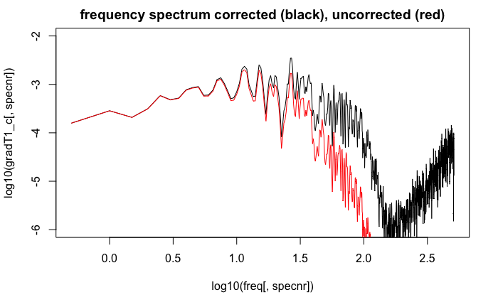

### Fit model to spectra with chi as parameter estimated with MLE

model to fit: psi_gradT(k) = C_T * chi * eps^-1/3 * k^1/3

with psi_gadT –> corrected energy spectrum,

C_T = Obukhov-Corrsin universal constant with values between 0.3 and 0.5, 0.4 recommended,

and k = wavenumber

#### plot model for some chi values

```r
C_T <- 0.4
chi <- c(10^(-5), 10^(-7), 10^(-9))
k <- waven1[,1]
psi <- matrix(NaN, nrow=length(k), ncol=length(chi))
for(chii in 1:length(chi)){
  psi[,chii] <- C_T * chi[chii] * eps1[1]^(-1/3) * k^(1/3)
}
```

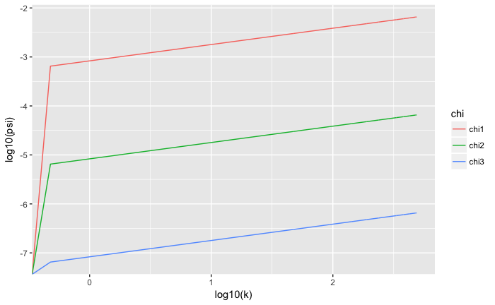

#### Convert measured spectra to wavenumber spectra

```r
P_gradT1_c <- matrix(NA, nrow = length(gradT1_c[,1]), ncol=length(gradT1_c[1,]))
for(index in 1:length(gradT1_c[,1])){
  P_gradT1_c[index,] <- gradT1_c[index,] * mean_speed
}
```

##### Choose spectrum to run model on

```r
specnr <- 102
segment <- specnr
```

```r
eps1 <- eps[1,]
mind <- length(waven1[waven1[,segment]<=10,segment]) # index for subsetting model values
y <- P_gradT1_c[1:mind,segment]   # corrected wavenumber temp-gradient spectrum --> P_gradT1_c
x <- waven1[1:mind,segment]
```

##### Definition of likelihood function

```r
#likelihood function definition
LL <- function(chi) {
  # Find residuals
  R = y - C_T * chi * eps1[segment]^(-1/3) * x^(1/3)
  # Calculate the likelihood for the residuals
  R = suppressWarnings(dnorm(R, log = TRUE))
  # Sum the log likelihoods for all of the data points
  -sum(R)
}
#model fit
fit <- suppressWarnings(mle(LL, start = list( chi=10^(-7))
                            ,nobs = length(y),  method='L-BFGS-B'))
```

```
Maximum likelihood estimation

Call:
mle(minuslogl = LL, start = list(chi = 10^(-7)), method = "L-BFGS-B",
    nobs = length(y))

Coefficients:
        Estimate   Std. Error
chi 1.476855e-06 0.0004213036

-2 log L: 40.4333
```

##### calculate model with fitted chi for plotting

```r
spec_model <-  C_T * fit@coef[1] * eps1[segment]^(-1/3) * x^(1/3)
```

##### plot data and model

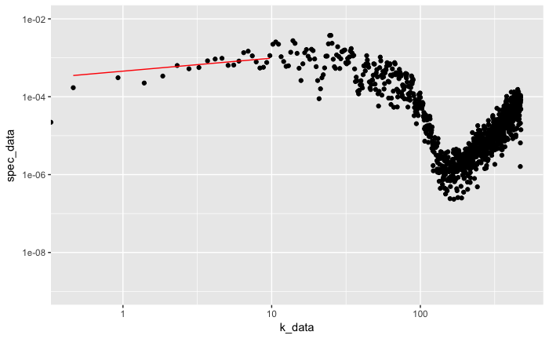

```r
pl_data <- data.frame(k_data=waven1[,segment], spec_data=P_gradT1_c[,segment])
pl_model <- data.frame(k_model = x[-1], spec_model = spec_model[-1])
ggplot() +
  geom_point(data=pl_data, aes(x=k_data, y = spec_data)) +
  geom_line(data=pl_model, aes(x=k_model, y=spec_model), color='red') +
  scale_y_continuous(trans='log10', limits=c(10^-9,10^-2)) +
  scale_x_log10()
```